# Note-Loss function

Weiquan Luo

2021-08-04

### Use of this document

The objective of this note is to explain the loss function from a statistical stand point, or specifically the maximum a posteriori estimation (MAP)

```r
library(tidyverse)
```

(source: https://www.cnblogs.com/LittleHann/p/9608599.html#_label0)  
(source: https://medium.com/jarvis-toward-intelligence/%E6%AF%94%E8%BC%83-cross-entropy-%E8%88%87-mean-squared-error-8bebc0255f5)  
(source: https://en.wikipedia.org/wiki/Loss_function)

# 1. Background

## 1.1 Distribution

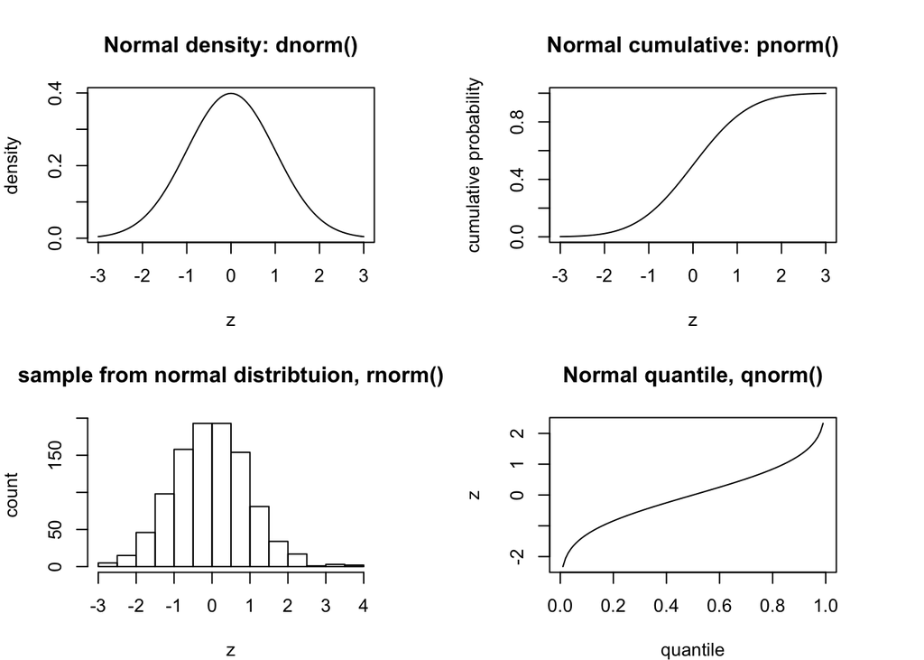

```r
par(mfrow = c(2,2), mar=c(4,4,4,4))
plot(function(x) dnorm(x), -3, 3,
     main = "Normal density: dnorm()", xlab = "z", ylab = "density")
plot(function(x) pnorm(x), -3, 3,
     main = "Normal cumulative: pnorm()", xlab = "z", ylab = "cumulative probability")
hist(rnorm(1000),
     main = "sample from normal distribtuion, rnorm()", xlab = "z", ylab = "count")
plot(function(x) qnorm(x),
     main = "Normal quantile, qnorm()", xlab = "quantile", ylab = "z")
```

The functions for the density/mass function, cumulative distribution function, quantile function and random variate generation are named in the form `dxxx`, `pxxx`, `qxxx` and `rxxx` respectively.

Functions for distributions functionalities provided by $stats$ package

[output not shown]

## 1.2 Statistical inference

- Orthogonal projections to ordinary least squares (OLS): Orthogonal projections to find the closed projection point on column plan, $X$. Using ordinal least squared method as the exmaple.
- Posterior distribution and maximum likelihood estimation (MLE)
- Prior probability distribution to Maximum a posteriori estimation (MAP)

## 1.3 The Norm

In mathematics, a norm is a function from a real or complex vector space to the nonnegative real numbers that behaves in certain ways like the distance from the origin.

The n-norm for vector is:

$$||X||_{n} = (\sum_{i=1}^{n} |x_i|^n)^{1/n}$$

The n-norm for Matrix is:

$$||A||_{n} = (\sum_{i=1}^{n} \sum_{j=1}^{n} |a_{ij}|^n)^{1/n}$$

Comparision between Vector Norm and Matrix Norm

| Type | Vector Norm | Matrix Norm |
| --- | --- | --- |
| 0-Norm (L0) | $\|\|X\|\|_{0} = \sum_{i=1}^{n} \|x_i\|^0$ | $\|\|A\|\|_{0} = \sum_{i=1}^{n} \|a_i\|^0$ |
| 1-Norm (L1) | $\|\|X\|\|_{1} = \sum_{i=1}^{n} \|x_i\|$ | $\|\|A\|\|_{1} = \max\limits_{1 \leq j \leq n} \sum_{i=1}^{n} \|a_i\|$ |
| 2-Norm (L2) also called Euclidean Norm, Frobenius-Norm | $\|\|X\|\|_{2} = \sqrt{\sum_{i=1}^{n} \|x_i\|^2}$ (i.e. $a^2 + b^2 + c^2$) | $\|\|A\|\|_{F} = \sqrt{\sum_{i=1}^{n} \sum_{j=1}^{n} \|a_{ij}\|^2}$ |
| P-Norm | $\|\|X\|\|_{p} = (\sum_{i=1}^{n} \|x_i\|^p)^{1/p}$ | $\|\|A\|\|_{p} = (\sum_{i=1}^{n} \sum_{j=1}^{n} \|a_{ij}\|^p)^{1/p}$ |
| $\infty$ -Norm | $\|\|X\|\|_{\infty} = \max\limits_{1 \leq j \leq n} \|x_{i}\|$ | $\|\|A\|\|_{\infty} = \max\limits_{1 \leq i \leq n} \sum_{j=1}^{n}\|a_{ij}\|$ |

## 1.4 Activation function

Common problems related to Activation function:

- Gradient exploding problem: large error gradients accumulate and result in very large updates to neural network model weights during training. Cause: 1) neural network is too deep; 2) too large learning rate.
- Vanishing gradient problem: With each subsequent layer the magnitude of the gradients gets exponentially smaller (vanishes) thus making the steps also very small which results in very slow learning of the weights in the lower layers of a deep network. Cause: 1) neural network is too deep; 2) magnitude of the activation function derivative is well below 1.0 in the whole range of the function and makes the gradients vanish quite fast.
- Not zero-centered: force either positive or negative update for all $\omega$ in backprop. i.e. sigmoid (mean = 0.5)
- high computational complexity: Slow learning speed require more trainning time for each updat. Cause: high computational complexity of activation functions, layers, etc. i.e Exponentiation in sigmoid an tanh
- Dead ReLU Problem: a large gradient flowing through a ReLU neuron could cause the weights to update in such a way that the neuron will never activate on any datapoint again, then the gradient flowing through the unit will forever be zero from that point on. Cause: 1) activation function where the gradient is always zero in some range. i.e. ReLU when x < 0, 2) parameter initiation result some neuron has x < 0 and are never activated during training.
- Infinite range: if the range of activation has either -$infty$ or $infty$, it can blow up the activation when the learning rate is too large.
- linearity: it can’t be used for the complex Classification. i.e. Leaky ReLUs lags behind the Sigmoid and Tanh for some of the use cases.

Common activation function. logits in tensorflow or pytroch could just refer to $X\omega$, no the logits function $log(\frac{p}{1+p})$.

| Activation function | Mathematical formulation | Prominent algorithm | problems |
| --- | --- | --- | --- |
| sigmoid (special case of the softmax function for a classifier with only two input classes) | $\sigma(x) = \frac{1}{1+e^{-x \omega}} = \frac{e^{x \omega}}{1+e^{x \omega}}$ | for convert to probability of the positive class in binary classification. | Gradient exploding problem; Vanishing gradient problem; Not zero-centered; high computational complexity |
| [Softmax](https://deepai.org/machine-learning-glossary-and-terms/softmax-layer) | $\sigma(\vec{z})_{i} = \frac{e^{z_i}}{\sum_{j=1}^{K} e^{z_j}}$ | convert to probabilities of j-class in multiclass classification. | - |
| tanh, or called Hyperbolic Tangent | $\frac{e^x-e^{-x}}{e^x+e^{-x}}$ | zero-centered | Gradient exploding problem; Vanishing gradient problem; high computational complexity |
| Rectified Linear Unit (ReLU) | $\sigma(x) = \max(x,0)$ | create non-linearity in stacking regressions; To avoid Gradient exploding problem and Vanishing gradient problem when $x>0$ | only gradient vanishing and Gradient exploding in $x > 0$; Not zero-centered; Dead ReLU Problem. Infinite range |
| Exponential Linear Unit (ELU) | $\begin{cases} x \ if \ x >0 \\ \alpha (e^x-1) \ if \ x \leq 0 \end{cases}$ | between ReLU and Leaky ReLU | high computational complexity. Infinite range |
| Leaky ReLU | $max(0.01x,x)$$ | improvement on ReLU; To avoid Gradient exploding problem and Vanishing gradient problem | Not zero-centered; Infinite range; linearity |
| PReLU | $max(\alpha,x)$, where $\alpha$ is learnt during trainnig | improvement on Leaky ReLU | Not zero-centered; Infinite range |
| Maxout | $for\ integer \ i \in [0,k],z_i = \omega_i x + b_i, out = max(z_i)$ | A combination of different activation function | high computational complexity with more parameter |

[Activation Functions](https://en.wikipedia.org/wiki/Activation_function) [pro and con of Activation Functions](https://ml-cheatsheet.readthedocs.io/en/latest/activation_functions.html#elu)

# 2. Objective function

## 2.1 maximum likelihood estimation (MLE)

In statistics, a **maximum likelihood estimation (MLE)** is a method of estimating the parameters of a probability distribution by maximizing a likelihood function. the objective function (or risk function) only consist of

- a likelihood function of data $X$ given parameter $\omega$.

$$likelihood: \ J(\hat{Y}, Y)_{MLE} = p(Y|X, \omega)$$

take $ln()$ at both side, become:

$$log\text -likelihood: \ L(\hat{Y}, Y) = ln(J(\hat{Y}, Y)_{MLE}) = \ln(p(Y|X, \omega))$$

## 2.2 Maximum a posteriori estimation (MAP)

In Bayesian statistics, a **Maximum a posteriori estimation (MAP)** estimate is an estimate of an unknown quantity, that equals the mode of the posterior distribution, or reverse probablity. The objective function (or risk function) consist of

- likelihood function of data $X$ given parameter $\omega$.
- prior distribution of parameter $\omega$.

$$likelihood: \ J(\hat{Y}, Y)_{MLE} = p(Y|X, \omega) p(\omega)$$

take $ln()$ at both side, become:

$$log\text -likelihood: \ L(\hat{Y}, Y)_{MAP} = \ln (p(Y|X, \omega) p(\omega)) = \ln (p(Y|X, \omega)) + \ln (p(\omega))$$

In mathematics, the arguments of the maxima (abbreviated arg max or argmax) are the points, or elements, of the domain of some function at which the function values are maximized. Supervised learning can be simply interpret as **finding parameters through minimizing your error while regularizing your parameters**.

$$\omega^* = \arg \max_\omega {\ln (p(Y|X, \omega)) + \ln (p(\omega))}$$

equivalent to

$$\omega^* = \arg \min_\omega - \ln (p(Y|X, \omega)) - \ln (p(\omega))$$

# 3. Minimize error: Loss term

$$ln(p(Y|X \omega)) \propto \frac{1}{n} \sum_{i=1}^{n} \ell(\hat{y_i},f(x_i;\omega)) = \frac{1}{n} \sum_{i=1}^{n} \ell(\hat{y_{i}}, y_{i})$$

## 3.1 Regression

relation between loss function of regression and various probability distributions corresponding to maximum likelihood procedure. $y_{i}$ is the observation, $\hat{y_{i}}$ is the estimate of $y_{i}$.

[output not shown]

## 3.2 Classification

relation between loss function of classification and various probability distributions corresponding to maximum likelihood procedure, where $y_{i}$ is the observation, $x_i \omega$ is the unnormalized estimate of probability of the predicted class, or unnormalized $logic$.

[output not shown]

Fitting Parameter via MLE for different distribution:

- [Exponential](https://www.real-statistics.com/distribution-fitting/distribution-fitting-via-maximum-likelihood/fitting-exponential-parameter-via-mle/)
- [Weibull](https://www.real-statistics.com/distribution-fitting/distribution-fitting-via-maximum-likelihood/fitting-weibull-parameters-mle/)
- [Gamma](https://www.real-statistics.com/distribution-fitting/distribution-fitting-via-maximum-likelihood/fitting-gamma-parameters-mle/)
- [Beta](https://www.real-statistics.com/distribution-fitting/distribution-fitting-via-maximum-likelihood/fitting-beta-distribution-parameters-mle/)
- [Uniform](https://www.real-statistics.com/distribution-fitting/distribution-fitting-via-maximum-likelihood/fitting-uniform-parameters-via-mle/)
- [Lognormal](https://www.real-statistics.com/distribution-fitting/distribution-fitting-via-maximum-likelihood/fitting-lognormal-distribution-via-mle/)
- [Gumbel](https://www.real-statistics.com/distribution-fitting/distribution-fitting-via-maximum-likelihood/fitting-gumbel-parameters-via-mle/)
- [Logistic](https://www.real-statistics.com/distribution-fitting/distribution-fitting-via-maximum-likelihood/fitting-logistic-parameters-via-mle/)
- [Geometric](https://www.real-statistics.com/distribution-fitting/distribution-fitting-via-maximum-likelihood/fitting-geometric-parameter-via-mle/)
- [Cauchy](https://www.real-statistics.com/distribution-fitting/distribution-fitting-via-maximum-likelihood/fitting-cauchy-parameters-via-mle/)

# 4. Regularizing parameters: Regularization term, or penalty

$$\ln (p(\omega)) \propto \lambda \Omega(\omega)$$

Common loss function for Regularization

| penalty | prior distribution of $\hat{\omega}$ | Mathematical formulation | Prominent used |
| --- | --- | --- | --- |
| L1 Loss, Mean Absolute Error | [Laplace](https://zhuanlan.zhihu.com/p/116079663) | $\|\omega\|$ | lasso |
| L2 Loss, Mean Square Error, Quadratic Loss | [Gaussian](https://zhuanlan.zhihu.com/p/116079663) | $\omega^2$ | ridge |